# Homework-03

Author

L. Harvey

## Homework #3

Background Code:

```r
library(tidyverse)
theme_set(theme_light(base_family = "Optima"))
```

## Exercise 3.1: Ignorability

Experiments work because they make the distribution of potential outcomes the same across levels of the treatment variable. In other words, the potential outcomes and the treatment indicator are *independent.*

This is how we discussed this idea in class:

Assume the following table comes from the perfectly-executed experiment.

**Table 3.1: Perfect Experiment Example**  
(Note that 30% of the population is in group $T = 1$.)

Fill in the missing cells. (Because this is the “perfect” experiment, there is no difference between the groups. Tah-dah!)

| Group $(T)$ | $E[Y^1]$ | $E[Y^0]$ |
| --- | --- | --- |
| $T$ = 1 | 10,000 | 5,000 |
| $T = 0$ | 10,000 | 5,000 |

Practice with the “naive estimate,” ATT, and ATC:

1. The naive estimate is based only on what we observe: 10,000 - 5,000 = 5,000.
2. The ATT is based on “magic”: 10,000 - 5,000 = 5,000
3. The ATC is based on (more) “magic”: 10,000 - 5,000 = 5,000

What is the ATE?

1. The ATE is the “switch” of effects: .30(5,000) + .70(5,000) = 1,500 + 3,500 = 5,000

```r
(.3 * 5000) + (.7 * 5000)
```

```
[1] 5000
```

## Exercise 3.2: Glossary

Go back to the first assignment and add the following words to the glossary:

1. **DAG** = A “DAG” is a “Directed Acyclic Graph.” This is a visual representation of causal relationships that uses arrows to illustrate how variables impact one another (i.e., Variable A causes B causes C, etc.).
2. **Paths** = In a DAG, “paths” show the causal, directional relationship between variables. Paths are denoted with directional arrows.
3. **Direct Effects** = The direct result of Variable A on Variable B, without any mediating variables or other pathways included.
4. **Indirect Effects** = The indirect result of Variable A on Variable B, which requires a mediating variable through Variable C to complete a pathway to Variable A.
5. **Total Effects** = Adding together both the direct and indirect effects of variables gives us the “total effect” of the variables on the outcome we’re studying.
6. **Front-Door Paths** = The most direct path from treatment variables to our outcome of interest (note that in front-door paths, this usually means that the direction of the arrows points away from treatment until the outcome variable, without doubling back on any variables).
7. **Back-Door Paths** = An indirect path from treatment variables to our outcome of interest (note that in back-door paths, directional movement through the pathway doubles back on other variables and takes the relationship through a side quest until it reaches the outcome variable of interest).
8. **Confounding** = A “confounding” variable is one that impacts both treatment *and* effect in a pathway.
9. **Collider =** A “collider” variable is a variable that has arrows from several variables “colliding” into it; We *never* control for collider variables, as doing so opens other pathways and makes tracing the causal relationship more difficult.
10. **Open Path =** A path is open if “all of the variables along that path are allowed to vary” (Huntington-Klein 122).
11. **Closed Path** = A path is closed if “at least one of the variables along that path has no variation” (Huntington-Klein 122).

## Exercise 3.3: Drawing DAGs

Draw a causal diagram for the research question, “Do long shift hours make doctors give lower-quality care?” that incorporates the following features (and only the following features):

1. Long shift hours affect both how tired doctors are, and how much experience they have, both of which affect the quality of care.

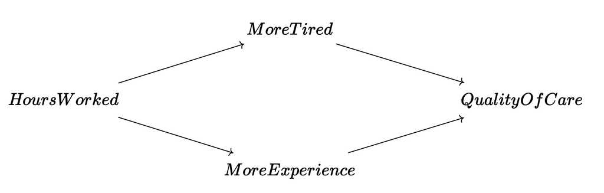

2. How long shifts are is often decided by the hospital the doctor works at. There are plenty of other things about a given hospital that also affect the quality of care, like its funding level, how crowded it is, and so on.

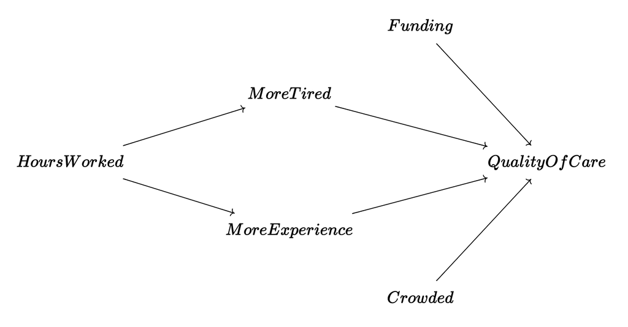

3. New policies that reduce shift times may be implemented at the same time (with the timing determined by some unobservable change in policy preferences) as other policies that also attempt to improve the quality of care.

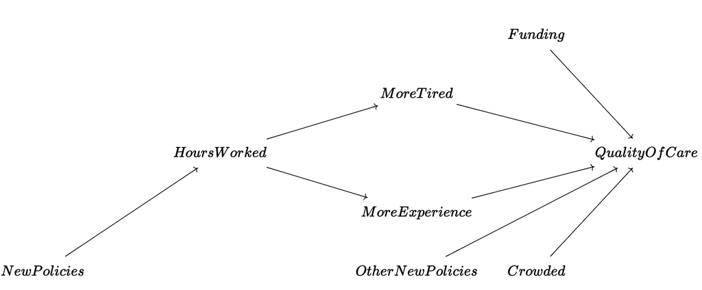

## Exercise 3.4: Public School Funding

Consider this research question: Does the funding level of public schools affect student achievement for students in your country?

a. What is the treatment and what is the outcome of interest?  
The treatment is “funding level of schools” and the outcome of interest is “student achievement” in the U.S.

b. Write down a list of relevant variables.  
Relevant variables include: The number of students in the school district, the funding level that the school receives, the number of teachers in the district, and the level of student achievement.

c. Which of the variables in your list in part b are causes of both treatment and outcome?  
Variables that may cause both treatment and outcome include: The number of students in the school district. This is because the funding that schools receive is calculated by the [“per pupil” expenditure](https://www.jstor.org/stable/1602446) (or how much money each student “costs” the school district).

d. Why might we want to pay extra attention to the variables listed in part c?  
We would want to pay extra attention to the variables listed in part c because these variables are “confounder” variables. In other words: If we fail to adjust for the variables in part c, then our the causal relationship in our data will likely be spurious and we will fail to accurately identify the effect we intended to examine.

e. Draw a causal diagram of the variables listed in part b.

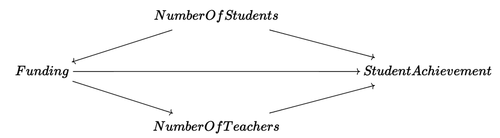

f. Simplify the diagram from part e.

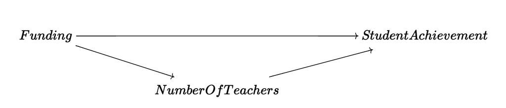

## **Exercise 3.5: Avoiding Cyclic Relationships**

The diagram below shows a cyclical relationship between student achievement and motivation. If students achieve more (i.e., score well on exams), then their motivation goes up, and if their motivation goes up, they achieve more. Change the diagram so that the relationship is not cyclic anymore.

Original Diagram:

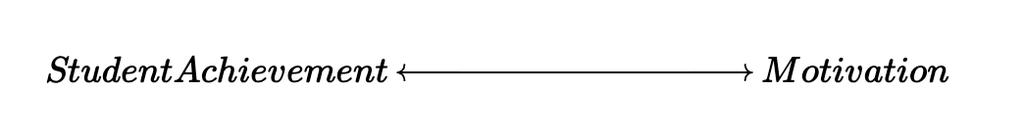

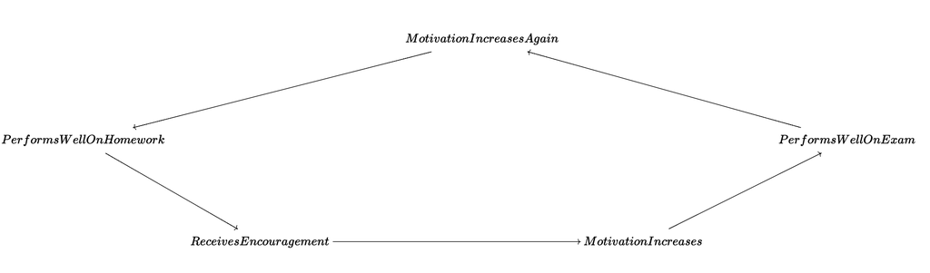

## Exercise 3.6: “Open” v. “Closed” Paths

Assuming that a path has no colliders on it, what is the difference between a path being “open” and “closed”?

1. The difference between a path being “open” and “closed” is that “open” paths allow for variance among **ALL** of the variables on the path, while “closed” paths refer to paths where “at least one of the variables” on the path has “no variation” (Huntington-Klein 122).

## Exercise 3.7: Evaluating the DAG

   The following paths are front-door paths:
   1. X —> A —> Y
3. Which of the paths are back-door paths?

   The back-door paths are as follows:
   1. X —> C —> D —> Y
   2. X —> B —> Y
   3. X —> B —> D —> Y
   4. X —> C —> D —> B —> Y
4. What variables must be controlled for in order to identify the effect of X on Y?
   1. In order to identify the effect of X on Y, we must control (or “adjust”) for Variable D.

## Exercise 3.8: Which of the Following..?

Which of the following describes a causal path where all the arrows point away from the treatment?

1. Open Path
2. Closed Path
3. Front Door Path
4. Back-Door Path

The answer is C) Front Door Path.

## Exercise 3.10: Dagglin’

Noodle around with the [Daggle application](https://cbdrh.shinyapps.io/daggle/) we used in class. Upload screenshots with the right answer for three DAGs with 4, 6, and 8 nodes each on the “difficult” complexity setting.

4-node DAG 1:

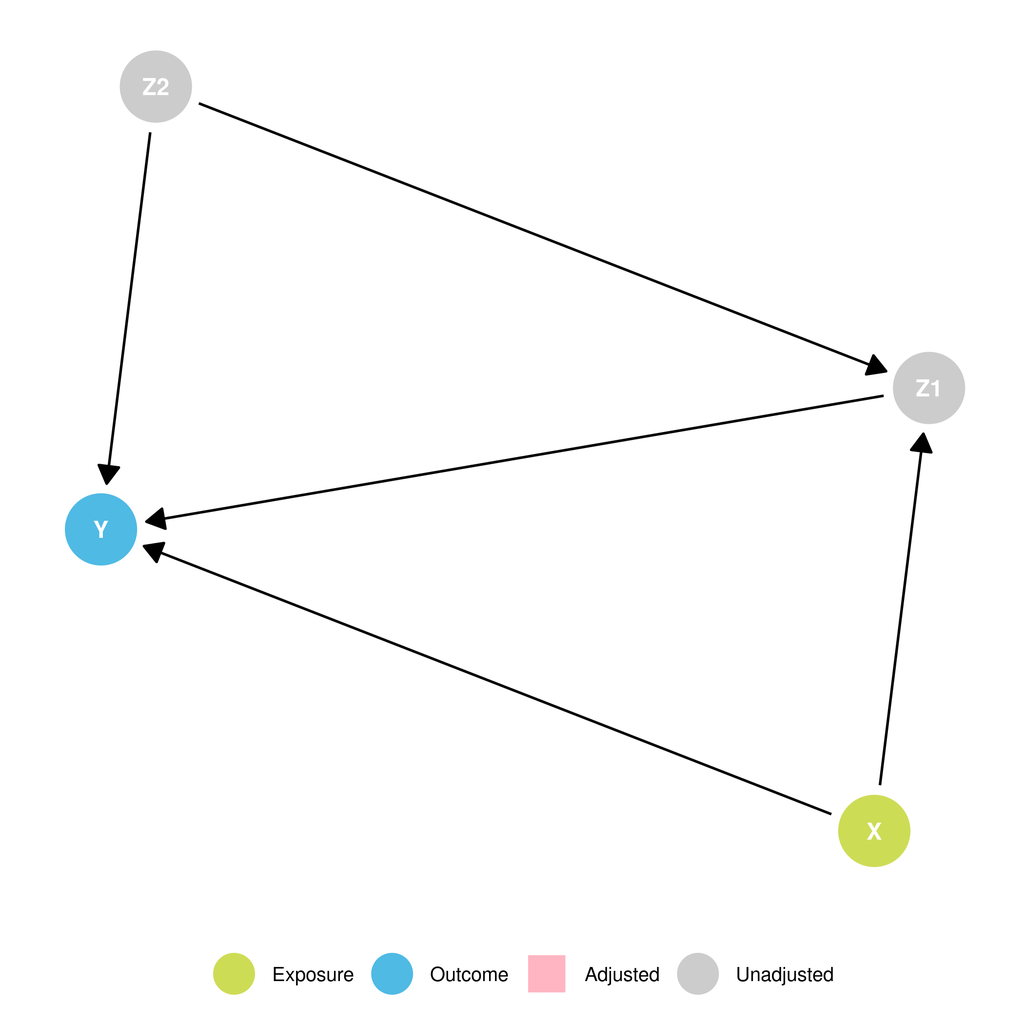

4-node DAG 2:

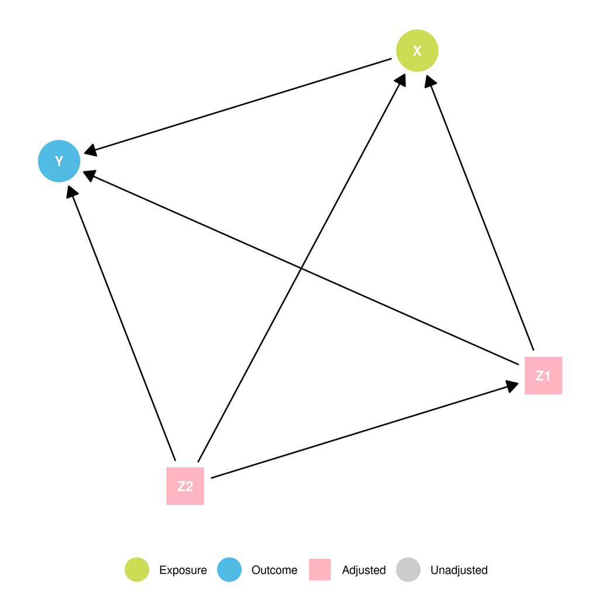

4-node DAG 3:

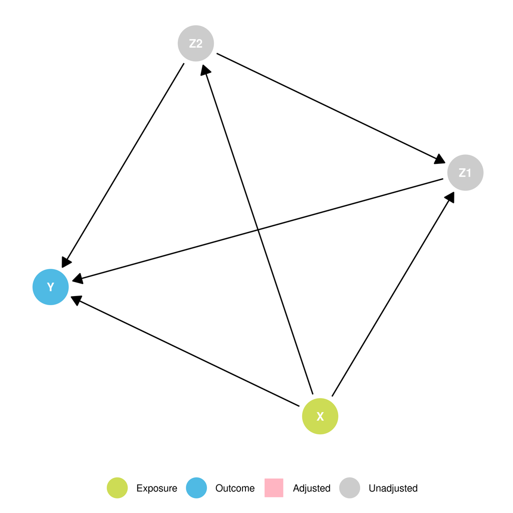

6-node DAG 1:

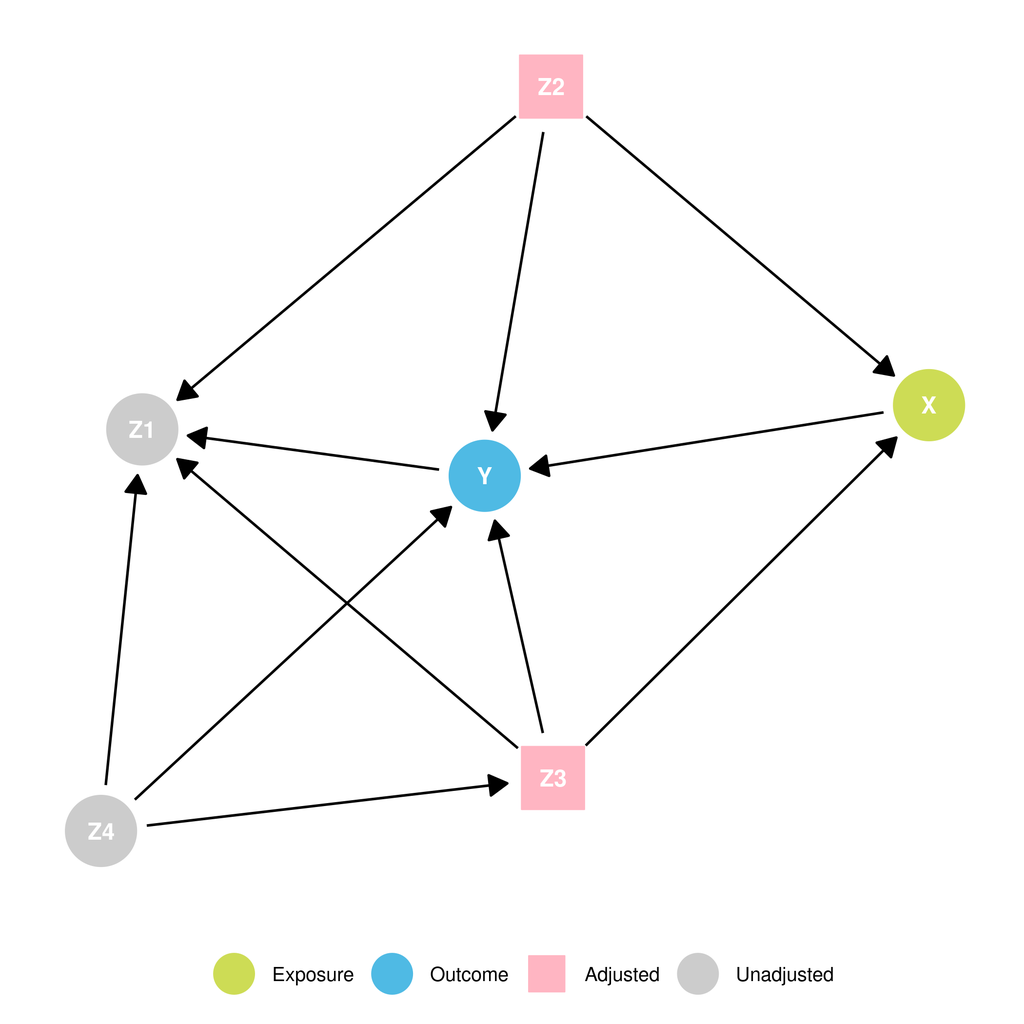

6-node DAG 2:

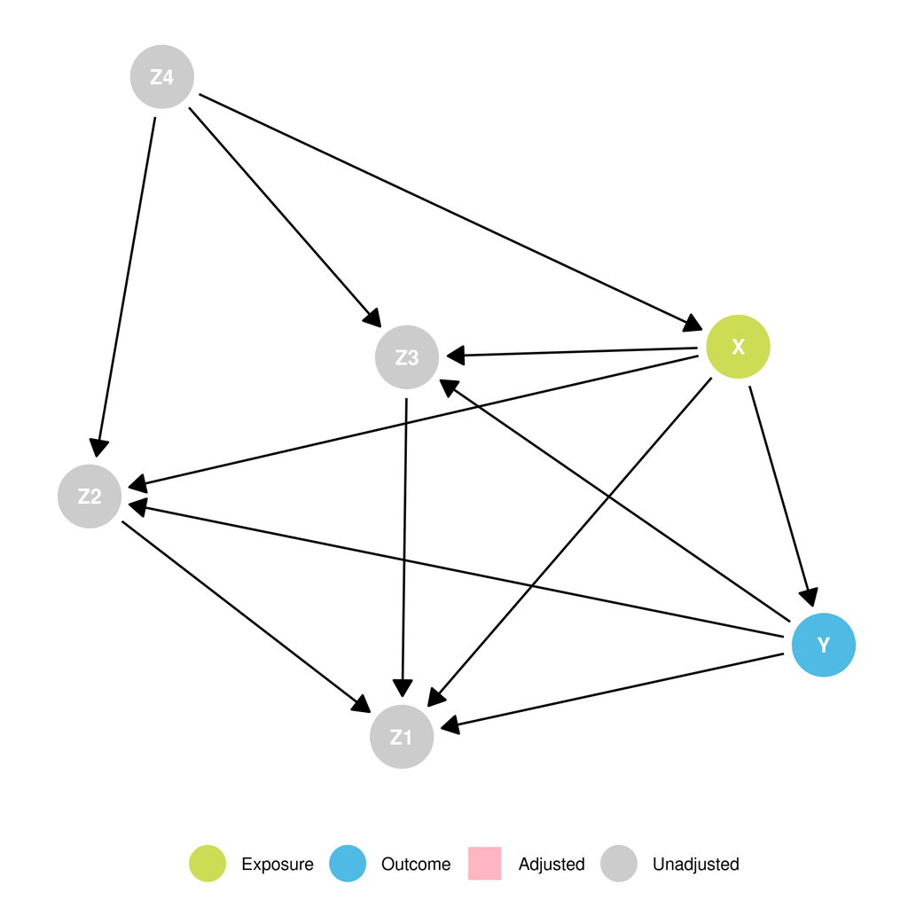

(Look at this guy!!! Tricky little bugger.)

6-node DAG 3:

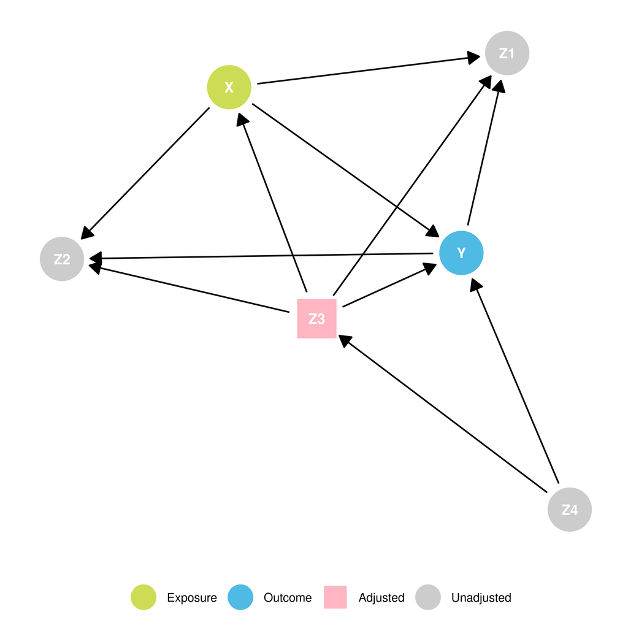

8-node DAG 1:

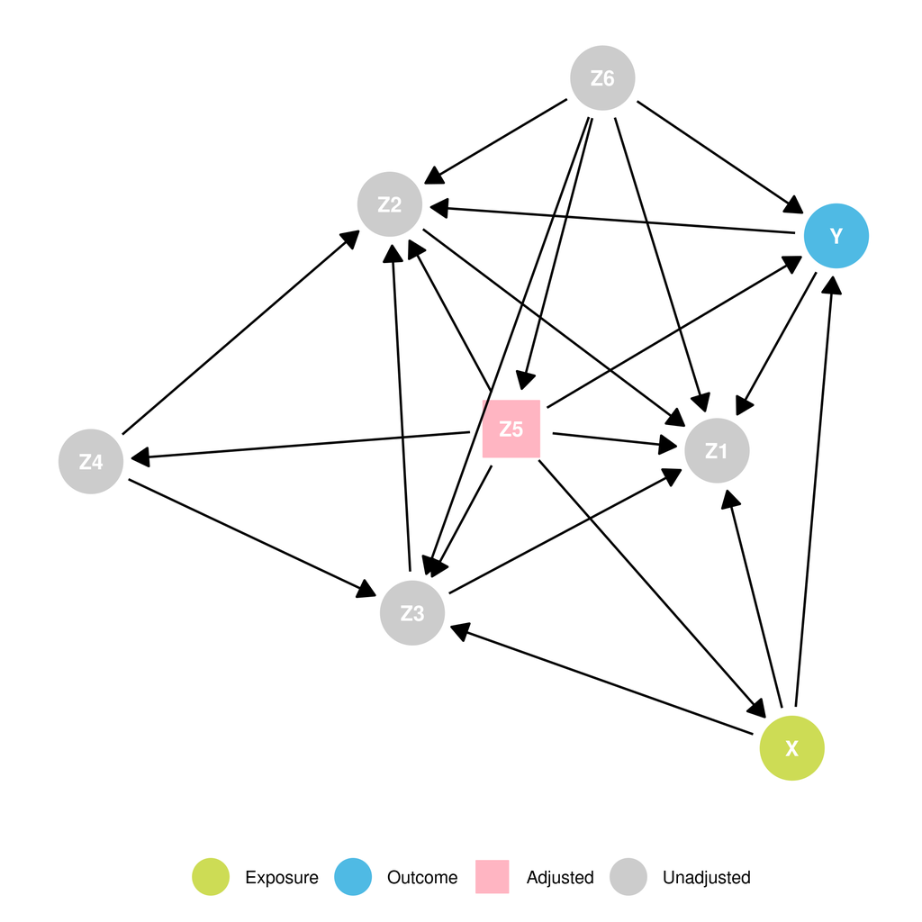

8-node DAG 2:

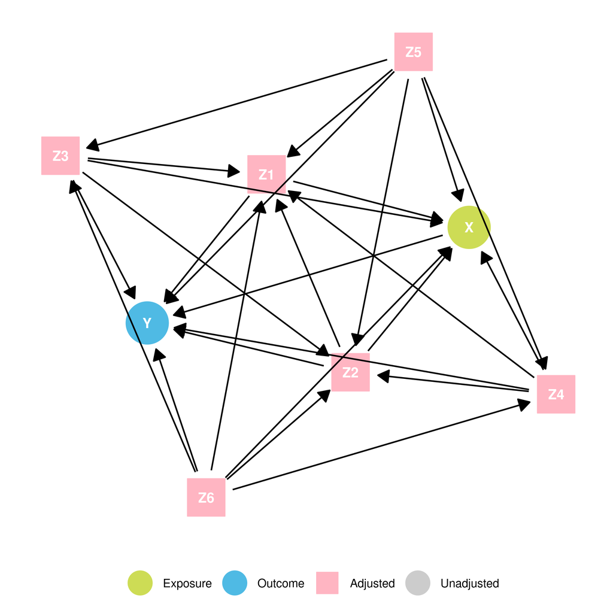

(You’ve gotta be kidding me.)

8-node DAG 3:

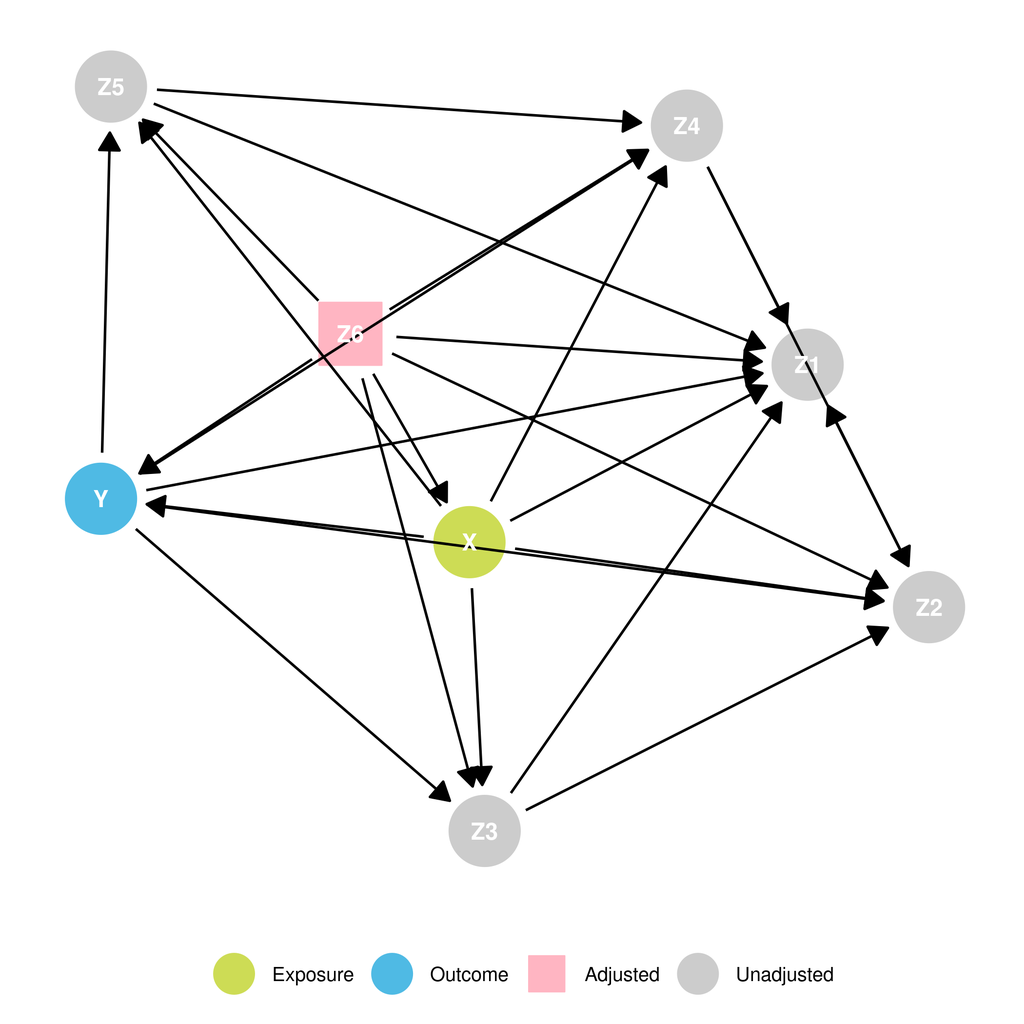

## Exercise 3.11: House of DAG

First, load Andres’ background code:

```r
hod_simulation <- function(
    N = 1e3,
    rho = 0.5,
    Bt = 1,
    Bx = 1
) {

  stopifnot(dplyr::between(rho, -1, 1))
  stopifnot(N > 0)

  Mu <- c(s = 1, x = 1)
  sigmas <- c(s = 1, x = 1)
  Rho <- rbind(c(1, rho), c(rho, 1))
  Sigma <- diag(sigmas) %*% Rho %*% diag(sigmas)
  d <- tibble::as_tibble(mvtnorm::rmvnorm(N, Mu, Sigma))
  ## approximately 50% of sample gets treatment with this hack
  d$t <- rbinom(N, 1, pnorm(d$s, Mu[["s"]], sigmas[["s"]]))

  e <- rnorm(N, 0, 5)

  d$y0 <- d$x*Bx + e
  d$y1 <- Bt + d$x*Bx + e
  d$y <- ifelse(as.logical(d$t), d$y1, d$y0)

  std_error <- sqrt(2*(5^2 + Bx^2) / (N/2))
  pwr <- pnorm(std_error*qnorm(0.975), Bt, std_error, lower.tail = FALSE)
  message("Standard Error ~ ", round(std_error, 3))
  message("Power ~ ", round(pwr, 3))

  out <- d[, c("x", "y0", "y1", "t", "y")]

  structure(out, class = c("simulation", class(out)), pars = list(N = N, Bt = Bt, Bx = Bx, rho = rho))

}
```

Load it using this code from the homework:

```r
library(tidyverse)
set.seed(12345) ## include this so that grading is easier for me.
d <- hod_simulation(N = 1e3, Bt = 2, Bx = 4, rho = 0.8)
```

```
Standard Error ~ 0.405
```

```
Power ~ 0.999
```

Question 1: Without looking at the results just yet, do you think that the naive estimate will be larger or smaller than the “real” estimate (wherein $ATE$ = 2)?  
Based on the fact that the naive estimate is a not-great way to assume the actual difference in treatments between groups, I think that the naive estimate will be larger than the $ATE$.  
Question 2: Check your answer. What are the results given by the naive estimator?  
To find the naive estimator, we first have to find the expected value for $Y^0$ and $Y^1$.

```r
d |> group_by(t) |>
  summarize(E_y1 = mean(y1), E_y0 = mean(y0))
```

```
# A tibble: 2 × 3
      t  E_y1  E_y0
  <int> <dbl> <dbl>
1     0  4.00  2.00
2     1  7.72  5.72
```

```r
# Subtracting to solve for the naive:
7.720 - 2.002
```

```
[1] 5.718
```

The output tells us that $E[Y^1]$ is 7.720 and that $E[Y^0]$ is 2.002—thus, the naive estimate is 5.718.

Question 3: Run the simulation again, but set `rho` to -0.8 (so that $S$ and $X$ are now negatively correlated).

```r
set.seed(12345)
second_sim <- hod_simulation(N = 1e3, Bt = 2, Bx = 4, rho = -0.8)
```

```
Standard Error ~ 0.405
```

```
Power ~ 0.999
```

```r
second_sim |>
  group_by(t) |>
  summarize(E_y1 = mean(y1), E_y0 = mean(y0))
```

```
# A tibble: 2 × 3
      t  E_y1  E_y0
  <int> <dbl> <dbl>
1     0  7.92  5.92
2     1  3.88  1.88
```

```r
# Find the naive again:
5.92 - 3.88
```

```
[1] 2.04
```

## Exercise 3.12: Randomizing

Take the dataset `d` from the previous question and modify it so that the treatment is now randomized (this will destroy the path between $S$ and $T$).

```r
set.seed(12345)
last_sim <- d
last_sim$t <- sample(last_sim$t)
last_sim$y <- if_else(last_sim$t == 1, last_sim$y1, last_sim$y0)
```

Question 1: Without looking at the results yet, do you think that the naive estimate will be larger or smaller than the “real” estimate ($ATE$ = 2)?  
I expect that the naive estimate will be bigger than the “real” $ATE$ estimate of 2.

Question 2: Check your answer. What are the results given by the naive estimator?

```r
last_sim |>
  group_by(t) |>
  summarize(E_y1 = mean(y1), E_y0 = mean(y0))
```

```
# A tibble: 2 × 3
      t  E_y1  E_y0
  <int> <dbl> <dbl>
1     0  5.90  3.90
2     1  5.97  3.97
```

```r
# Finding the naive estimate:
5.97 - 3.90
```

```
[1] 2.07
```

Running this code gives an output of $E[Y^1]$ = 5.97 and $E[Y^0]$ = 3.90. Thus, the naive estimate is 2.07.

Question 3: Use `lm` to predict the newly-created `y` from `t`. What are the coefficient values?

```r
lm(formula = y ~ t, data = last_sim)
```

```
Call:
lm(formula = y ~ t, data = last_sim)

Coefficients:
(Intercept)            t
      3.902        2.066
```

The coefficient values are as follows: $T$ = 2.066 and $\alpha$ = 3.902.

Question 4: Use `lm` to predict the newly-created `y` from `t` and `x`. What are the coefficient values?

```r
lm(formula = y ~ t + x, data = last_sim)
```

```
Call:
lm(formula = y ~ t + x, data = last_sim)

Coefficients:
(Intercept)            t            x
    -0.3111       2.1038       4.1771
```

The coefficient values are as follows: $T$ = 2.104, $X$ = 4.177, and $\alpha$ = -0.311